# Biodiversity across dairy samples in a skim milk powder manufacturing pipeline

Kailyn Hanke

2025-04-09

Now that we have our rooted phylogenetic tree, with this document is to complete an analysis on the within-sample biodiversity of the dairy samples across this skim milk manufacturing pipeline.

# Goals

1. Calculate the Hill Numbers of the samples using the iNEXT package.
2. Plot and evaluate the interpolated and extrapolated rarefaction curves from iNEXT.
3. Analyze the Hill numbers as it relates to sample type.
4. Test and then answer the scientific question at hand! (Remember, we’re doing biology!)
1. We will need the `phytree_preprocessed_physeq`, which includes a rooted tree (ideally within the archaea!) that we created in `analysis/04B_Phylogenetic_Tree_Inspection.Rmd`.

## Outputs

1. Calculated biodiversity measures (Hill numbers) across every sample.
2. Figures to include in our scientific paper that visualize the data as it relates to the scientific question.
3. Statistical tests conveying the measured and quantified changes and patterns in biodiversity.

# Scientific Question

## Question & Hypotheses

My primary scientific question: How does the microbial diversity of dairy samples change throughout the skim milk powder manufacturing process?

In this document I would like to explore, specifically, how the alpha (within-sample) diversity changes in the dairy samples as the raw milk is processed to become skim milk powder.

- *Null Hypothesis:* Microbial alpha diversity (*e.g.* richness and Simpson diversity) does not vary as the raw milk is processed (as it goes from farm bulk tank milk to its final form of skim milk powder).
- *Alternative Hypothesis:* Microbial alpha diversity (*e.g.* richness and Simpson diversity) decreases as the raw milk is processed to become skim milk powder.

## Field site background

To answer this specific scientific question, I re-rean analysis on data from a 2020 paper titled “Tracking the Dairy Microbiota from Farm Bulk Tank to Skimmed Milk Powder” [@mchughTrackingDairyMicrobiota2020]. In this study they used 16S gene sequencing to track the microbiota of raw milks on farms to a final skimmed milk powder product. In this manufacturing pipline they took dairy samples from six different places in the manufacturing pipeline. They also collected samples during two different seasons (find season-based analysis in 08_Seasonal_Biodiversity).

# Set up the Environment

## Timing of this script

```r
# What time did we start running this script?
start_time <- Sys.time()
```

## Set the seed

```r
set.seed(111111)
```

## Load Packages & Colors

```r
#install packages for stats
#install.packages("rstatix")
#install.packages("ggpubr")
#install.packages("FSA")
#install.packages("rstatix")


pacman::p_load(tidyverse, devtools, patchwork, iNEXT, phyloseq,
               # packages for stats
               ggpubr, rstatix, FSA, install = FALSE)


# Load in colors for plotting
source("code/colors.R")

#Load in iNEXT data
load("data/05_Biodiversity/iNEXT_data_cut.RData")
```

## Load in Data

```r
load("data/04_PhylogeneticTree/midpoint_rooted_physeq.RData")

# take a look at it!
midpoint_rooted_physeq
```

```
## phyloseq-class experiment-level object
## otu_table()   OTU Table:         [ 71237 taxa and 201 samples ]
## sample_data() Sample Data:       [ 201 samples by 55 sample variables ]
## tax_table()   Taxonomy Table:    [ 71237 taxa by 9 taxonomic ranks ]
## phy_tree()    Phylogenetic Tree: [ 71237 tips and 71236 internal nodes ]
```

```r
# Intuition check on seq depth
range(sample_sums(midpoint_rooted_physeq)) #Range was 12 - 170404
```

```
## [1]     12 170404
```

```r
# Investigate further
# Order sample sums from lowest to highest and show the first 20
#head(sort(sample_sums(raw_physeq)), 20) # min = 556
#head(sort(sample_sums(noChloros_physeq)), 20) #min = 556
#head(sort(sample_sums(noChlorosMitos_physeq)), 20) #min = 553
#head(sort(sample_sums(raw_preprocessed_physeq)), 20) #min = 1524
#head(sort(sample_sums(unrooted_physeq)), 20) #min = 1524

#after pruning the min changes from 1524 to 12!

#head(sort(sample_sums(unrooted_physeq_rm115706)), 20) #min = 12, 04B line 245
#head(sort(sample_sums(unrooted_physeq_rm115706_rmarchaea)), 20) #min = 12
#head(sort(sample_sums(midpoint_rooted_physeq)), 20) #min = 12


#Okay, good thing I ran intuition check!!

#Making a dataframe to inspect further.
sample_depths_rooted <- data.frame(
  Sample = sample_names(midpoint_rooted_physeq),
  Depth = sample_sums(midpoint_rooted_physeq)
)

# Sort it from lowest to highest
sample_depths_rooted_sorted <- sample_depths_rooted[order(sample_depths_rooted$Depth), ]

head(sample_depths_rooted_sorted, n=20)  # lowest depth is 12!
```

```
##                Sample Depth
## ERR3143469 ERR3143469    12
## ERR3143473 ERR3143473    17
## ERR3143475 ERR3143475    26
## ERR3143461 ERR3143461    28
## ERR3143468 ERR3143468    41
## ERR3143472 ERR3143472    57
## ERR3143463 ERR3143463   129
## ERR3143467 ERR3143467   165
## ERR3143471 ERR3143471   183
## ERR3141454 ERR3141454  4428
## ERR3141501 ERR3141501  9143
## ERR3141434 ERR3141434  9920
## ERR3141489 ERR3141489 17924
## ERR3141496 ERR3141496 18811
## ERR3141543 ERR3141543 18944
## ERR3141539 ERR3141539 19423
## ERR3141520 ERR3141520 20090
## ERR3141488 ERR3141488 21006
## ERR3141503 ERR3141503 21026
## ERR3141433 ERR3141433 21204
```

```r
# Remove the 9 samples with mins of 12 - 183
# Removed these after the tree was already rooted - consequences??
midpoint_rooted_physeq_cut <-
  midpoint_rooted_physeq %>%
  subset_samples(!(names %in% c("ERR3143469", "ERR3143473", "ERR3143475", "ERR3143461", "ERR3143468",
                                "ERR3143472", "ERR3143463", "ERR3143467", "ERR3143471")))

head(sort(sample_sums(midpoint_rooted_physeq_cut)), 20) #min = 4428
```

```
## ERR3141454 ERR3141501 ERR3141434 ERR3141489 ERR3141496 ERR3141543 ERR3141539
##       4428       9143       9920      17924      18811      18944      19423
## ERR3141520 ERR3141488 ERR3141503 ERR3141433 ERR3141546 ERR3141535 ERR3141402
##      20090      21006      21026      21204      21282      23166      24490
## ERR3141415 ERR3141527 ERR3141538 ERR3141435 ERR3141432 ERR3141551
##      25301      25605      25829      25871      26489      28440
```

## Extra steps - miscellaneous troubleshooting!!

```r
# #Root tree without the 9 samples I cut above! (cut samples out before)
#
# # Check to see if tree is rooted.. expect it to be false
# is.rooted(phy_tree(unrooted_physeq_rm115706_rmarchaea))
#
#
# #trim the 9 samples before rooting
#
# unrooted_physeq_rm115706_rmarchaea_cut <-
#   unrooted_physeq_rm115706_rmarchaea %>%
#   subset_samples(!(names %in% c("ERR3143469", "ERR3143473", "ERR3143475", "ERR3143461", "ERR3143468",
#                                 "ERR3143472", "ERR3143463", "ERR3143467", "ERR3143471")))
#
# head(sort(sample_sums(unrooted_physeq_rm115706_rmarchaea_cut)), 20) #min = 4428
#
# # Let's midpoint root the tree
# midpoint_rooted_tree_Finalcut <-
#   unrooted_physeq_rm115706_rmarchaea_cut %>%
#   phy_tree() %>%
#   phytools::midpoint.root()
#
# # Is the new tree rooted? Should be TRUE!
# is.rooted(midpoint_rooted_tree_Finalcut)
#
# # Assign to a new phyloseq object!
# midpoint_rooted_physeq_Finalcut <-
#   merge_phyloseq(raw_preprocessed_physeq, midpoint_rooted_tree_Finalcut)
#
# #Plot midpoint rooted tree
#
# # Quick inspection of tree
# midpoint_rooted_tree_Finalcut_plot <-
#   ggtree(midpoint_rooted_physeq_Finalcut) +
#   geom_tippoint(mapping = aes(color = Kingdom)) +
#   geom_tippoint(aes(color = Kingdom)) +
#   labs(title = "Midpoint Rooted Tree (Cut)") +
#   scale_color_manual(values = c("firebrick3", "cornflowerblue", "grey"))
#
# # Look at the tree
# midpoint_rooted_tree_Finalcut_plot
#
# head(sort(sample_sums(midpoint_rooted_physeq_Finalcut)), 20) #min = 12
#
# #I'm not sure why I have min = 12 again! Is it because I used raw_preprocessed_physeq for my merge step?
# #Should I merge my original midpoint_rotted_tree with unrooted_physeq_rm115706_rmarchaea???
# #Here I will now try merging with unrooted_physeq_rm115706_rmarchaea_cut instead...
#
# # Assign to a new phyloseq object!
# midpoint_rooted_physeq_Finalcut <-
#   merge_phyloseq(unrooted_physeq_rm115706_rmarchaea_cut, midpoint_rooted_tree_Finalcut)
#
# head(sort(sample_sums(midpoint_rooted_physeq_Finalcut)), 20) #min = 4428
#
# #okay this seems promising
#
# midpoint_rooted_tree_Finalcut_plot_revised <-
#   ggtree(midpoint_rooted_physeq_Finalcut) +
#   geom_tippoint(mapping = aes(color = Kingdom)) +
#   geom_tippoint(aes(color = Kingdom)) +
#   labs(title = "Midpoint Rooted Tree (Cut2)") +
#   scale_color_manual(values = c("firebrick3", "cornflowerblue", "grey"))
#
# #Got this error: Error in el[phy$edge[, 2]] <- phy$edge.length : replacement has length zero
# #Trying to fix
#
# # phyloseq object to a new object
# midpoint_rooted_physeq_Finalcut_fixed <- unrooted_physeq_rm115706_rmarchaea_cut
#
# # assign the rooted tree into the new phyloseq object
# phy_tree(midpoint_rooted_physeq_Finalcut_fixed) <- midpoint_rooted_tree_Finalcut
#
# # make sure edge lengths are present
# phy_tree(midpoint_rooted_physeq_Finalcut_fixed)$edge.length
#
# #plot it out!!
#
# midpoint_rooted_tree_plot_fixed <-
#   ggtree(midpoint_rooted_physeq_Finalcut_fixed) +
#   geom_tippoint(aes(color = Kingdom)) +
#   labs(title = "Midpoint Rooted Tree (Cut) — Fixed") +
#   scale_color_manual(values = c("firebrick3", "cornflowerblue", "grey")) +
#   theme(legend.position = "bottom")
#
# # view plot
#
# midpoint_rooted_tree_plot_fixed
```

## Let’s continue with midpoint_rooted_physeq_cut

```r
# Save midpoint rooted phyloseq object
save(midpoint_rooted_physeq_cut,
     file = "data/05_Biodiversity/midpoint_rooted_physeq_cut.RData")

# Intuition check on seq depth
min(sample_sums(midpoint_rooted_physeq_cut))
```

```
## [1] 4428
```

```r
# Make a metadata dataframe
metadata_df_cut <-
  midpoint_rooted_physeq_cut %>%
  sample_data() %>%
  data.frame()

# view of it
glimpse(metadata_df_cut)
```

```
## Rows: 192
## Columns: 55
## $ Assay.Type                               <chr> "AMPLICON", "AMPLICON", "AMPL…
## $ AvgSpotLen                               <dbl> 502, 502, 502, 502, 502, 502,…
## $ Bases                                    <dbl> 99546098, 90531684, 211145718…
## $ BioProject                               <chr> "PRJEB31110", "PRJEB31110", "…
## $ BioSample                                <chr> "SAMEA5320046", "SAMEA5320047…
## $ Bytes                                    <dbl> 62822225, 54410542, 129707696…
## $ Center.Name                              <chr> "TEAGASC FOOD RESEARCH CENTRE…
## $ Collection_Date                          <chr> "5/18/2016", "5/18/2016", "5/…
## $ Consent                                  <chr> "public", "public", "public",…
## $ DATASTORE.filetype                       <chr> "fastq,run.zq,sra", "fastq,ru…
## $ DATASTORE.provider                       <chr> "ena,gs,ncbi,s3", "ena,gs,ncb…
## $ DATASTORE.region                         <chr> "ena,gs.us-east1,ncbi.public,…
## $ ENA.FIRST.PUBLIC..run.                   <chr> "2/20/2019", "2/20/2019", "2/…
```

[output cut: 42 more lines]

```r
#Save it in data file
write.csv(metadata_df_cut, "data/05_Biodiversity/metadata_df_cut.csv", row.names = TRUE)
```

# Biodiversity Hill Numbers with iNEXT

```r
# prepare the input data
# Species in rows and the samples in columns
iNEXT_input_df_cut <-
  midpoint_rooted_physeq_cut %>%
  otu_table() %>%
  data.frame()

# Inpect
dim(iNEXT_input_df_cut)
```

```
## [1] 71237   192
```

```r
iNEXT_input_df_cut[1:5, 1:5]
```

```
##           ERR3141386 ERR3141387 ERR3141388 ERR3141389 ERR3141390
## ASV_0012           0        425        104          0          0
## ASV_44992          0          0          0          0          0
## ASV_41984          0          0          0          0          0
## ASV_41513          0          0          0          0          0
## ASV_28999          0          0          0          0          0
```

```r
# Run iNEXT
# Remember to set the seed!
# ASVs in ROWs, samples in COLUMNS
#iNEXT_data_cut <- iNEXT(iNEXT_input_df_cut,
                   #q = c(0, 1, 2),
                   #datatype = "abundance")

# Inspect
str(iNEXT_data_cut)
```

```
## List of 3
##  $ DataInfo:'data.frame':    192 obs. of  14 variables:
##   ..$ Assemblage: chr [1:192] "ERR3141386" "ERR3141387" "ERR3141388" "ERR3141389" ...
##   ..$ n         : num [1:192] 60940 46996 170404 109440 52079 ...
##   ..$ S.obs     : num [1:192] 823 976 880 473 630 ...
##   ..$ SC        : num [1:192] 1 1 1 1 1 ...
##   ..$ f1        : num [1:192] 33 19 42 16 19 9 12 31 52 28 ...
##   ..$ f2        : num [1:192] 74 60 92 46 35 53 34 73 109 67 ...
##   ..$ f3        : num [1:192] 89 125 132 75 71 65 43 182 190 150 ...
##   ..$ f4        : num [1:192] 47 63 68 40 28 30 41 69 89 64 ...
##   ..$ f5        : num [1:192] 33 44 47 24 8 19 13 41 53 35 ...
##   ..$ f6        : num [1:192] 39 30 36 19 3 12 17 35 41 34 ...
##   ..$ f7        : num [1:192] 26 32 27 22 5 8 18 26 53 40 ...
##   ..$ f8        : num [1:192] 25 28 14 5 4 10 9 30 30 37 ...
##   ..$ f9        : num [1:192] 25 25 24 13 3 12 10 17 39 41 ...
##   ..$ f10       : num [1:192] 24 28 9 7 4 5 12 24 36 29 ...
##  $ iNextEst:List of 2
##   ..$ size_based    :'data.frame':   23040 obs. of  10 variables:
##   .. ..$ Assemblage: chr [1:23040] "ERR3141386" "ERR3141386" "ERR3141386" "ERR3141386" ...
##   .. ..$ m         : num [1:23040] 1 3386 6771 10157 13542 ...
##   .. ..$ Method    : chr [1:23040] "Rarefaction" "Rarefaction" "Rarefaction" "Rarefaction" ...
##   .. ..$ Order.q   : num [1:23040] 0 0 0 0 0 0 0 0 0 0 ...
##   .. ..$ qD        : num [1:23040] 1 412 538 610 659 ...
##   .. ..$ qD.LCL    : num [1:23040] 1 408 532 604 651 ...
##   .. ..$ qD.UCL    : num [1:23040] 1 416 544 617 666 ...
##   .. ..$ SC        : num [1:23040] 0.0556 0.9474 0.9732 0.9829 0.988 ...
##   .. ..$ SC.LCL    : num [1:23040] 0.0546 0.9466 0.9727 0.9825 0.9877 ...
##   .. ..$ SC.UCL    : num [1:23040] 0.0566 0.9482 0.9736 0.9833 0.9883 ...
##   ..$ coverage_based:'data.frame':   22725 obs. of  8 variables:
##   .. ..$ Assemblage: chr [1:22725] "ERR3141386" "ERR3141386" "ERR3141386" "ERR3141386" ...
##   .. ..$ SC        : num [1:22725] 0.0556 0.9474 0.9732 0.9829 0.988 ...
##   .. ..$ m         : num [1:22725] 1 3386 6771 10157 13542 ...
##   .. ..$ Method    : chr [1:22725] "Rarefaction" "Rarefaction" "Rarefaction" "Rarefaction" ...
##   .. ..$ Order.q   : num [1:22725] 0 0 0 0 0 0 0 0 0 0 ...
##   .. ..$ qD        : num [1:22725] 1 412 538 610 659 ...
##   .. ..$ qD.LCL    : num [1:22725] 0.991 404.974 529.947 601.515 649.479 ...
##   .. ..$ qD.UCL    : num [1:22725] 1.01 418.69 545.68 618.74 667.72 ...
##  $ AsyEst  :'data.frame':    576 obs. of  7 variables:
##   ..$ Assemblage: chr [1:576] "ERR3141386" "ERR3141386" "ERR3141386" "ERR3141387" ...
##   ..$ Diversity : chr [1:576] "Species richness" "Shannon diversity" "Simpson diversity" "Species richness" ...
##   ..$ Observed  : num [1:576] 823 73.1 18 976 194.5 ...
##   ..$ Estimator : num [1:576] 830.4 73.6 18 979 196.6 ...
##   ..$ s.e.      : num [1:576] 8.808 0.587 0.152 8.104 1.782 ...
##   ..$ LCL       : num [1:576] 823 72.4 17.7 976 193.1 ...
##   ..$ UCL       : num [1:576] 847.6 74.7 18.3 994.9 200.1 ...
##  - attr(*, "class")= chr "iNEXT"
```

```r
typeof(iNEXT_data_cut)
```

```
## [1] "list"
```

```r
save(iNEXT_data_cut, file = "data/05_Biodiversity/iNEXT_data_cut.RData")
```

# Rarefaction Curves

## `ggiNEXT` Rarefaction Curves

```r
# Prepare Colors
color_df_cut <-
  iNEXT_input_df_cut %>%
  colnames() %>%
  data.frame()
# Check
head(color_df_cut)
```

```
##            .
## 1 ERR3141386
## 2 ERR3141387
## 3 ERR3141388
## 4 ERR3141389
## 5 ERR3141390
## 6 ERR3141391
```

```r
# Rename the column
colnames(color_df_cut)[1] <- "names"
# Check
head(color_df_cut)
```

```
##        names
## 1 ERR3141386
## 2 ERR3141387
## 3 ERR3141388
## 4 ERR3141389
## 5 ERR3141390
## 6 ERR3141391
```

```r
# Make a helper dataframe for plotting with colors
iNEXT_color_df_cut <-
  color_df_cut %>%
  # Merge with metadata
  left_join(metadata_df_cut, by = "names") %>%
  # Merge with colors for plotting with ggiNEXT
  left_join(data.frame(environment_colors = environment_colors,
            environment_material = names(environment_colors)),
            by = "environment_material")

head(iNEXT_color_df_cut)
```

```
##        names Assay.Type AvgSpotLen     Bases BioProject    BioSample     Bytes
## 1 ERR3141386   AMPLICON        502  99546098 PRJEB31110 SAMEA5320046  62822225
## 2 ERR3141387   AMPLICON        502  90531684 PRJEB31110 SAMEA5320047  54410542
## 3 ERR3141388   AMPLICON        502 211145718 PRJEB31110 SAMEA5320048 129707696
## 4 ERR3141389   AMPLICON        502 112309448 PRJEB31110 SAMEA5320049  66426848
## 5 ERR3141390   AMPLICON        502 127532598 PRJEB31110 SAMEA5320050  79143820
## 6 ERR3141391   AMPLICON        502  68124412 PRJEB31110 SAMEA5320051  40072504
##                    Center.Name Collection_Date Consent DATASTORE.filetype
## 1 TEAGASC FOOD RESEARCH CENTRE       5/18/2016  public   fastq,run.zq,sra
## 2 TEAGASC FOOD RESEARCH CENTRE       5/18/2016  public   fastq,run.zq,sra
## 3 TEAGASC FOOD RESEARCH CENTRE       5/18/2016  public   fastq,run.zq,sra
## 4 TEAGASC FOOD RESEARCH CENTRE       5/18/2016  public   fastq,run.zq,sra
## 5 TEAGASC FOOD RESEARCH CENTRE       5/18/2016  public   fastq,run.zq,sra
## 6 TEAGASC FOOD RESEARCH CENTRE       5/18/2016  public   fastq,run.zq,sra
##   DATASTORE.provider                         DATASTORE.region
```

[output cut: 90 more lines]

```r
dim(iNEXT_color_df_cut)
```

```
## [1] 192  56
```

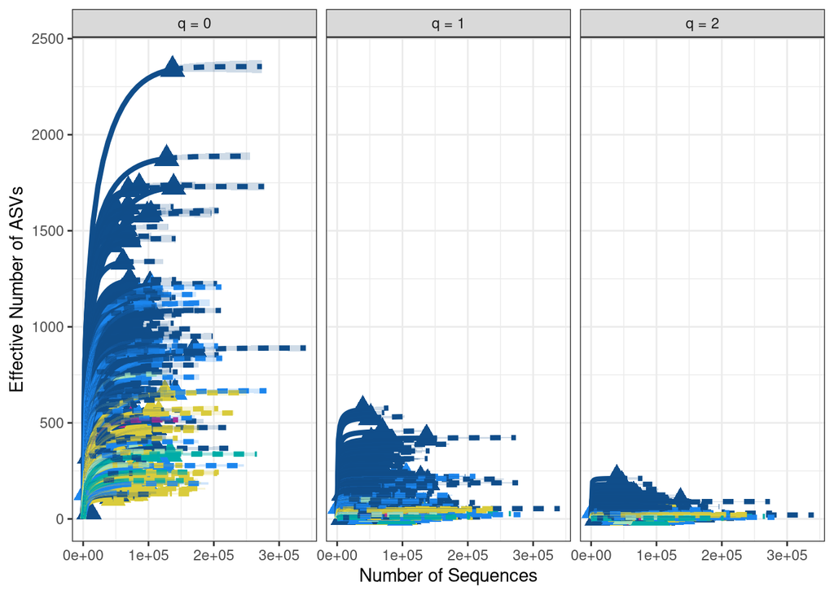

```r
ggiNEXT(iNEXT_data_cut, type = 1, facet.var = "Order.q") +
  scale_color_manual(values = iNEXT_color_df_cut$environment_colors) +
  scale_fill_manual(values = iNEXT_color_df_cut$environment_colors) +
  scale_shape_manual(values = base::rep(17, nsamples(midpoint_rooted_physeq_cut))) +
  theme_bw() +
  theme(legend.position = "none") +
  labs(y = "Effective Number of ASVs", x = "Number of Sequences")
```

A note to help understand what is going on for future me:

Remembering that an Order q of:

- 0 = Richness/ Number of Total taxa
- 1 = Exponential Shannon / Number of “Common” taxa
- 2 = Inverse Simpson / Number of “Dominant” taxa
1. The best gift of the Hill Numbers: *All three diversity measures are on the same x-axis: The Effective Number of Species or ASVs.*
2. As q increases from 0 to 1 to 2, the abundance of the species is weighted more, so the rarefaction curve plateaus earlier. This is important because it **indicates that richness is the most sensitive to sequencing depth!** However, Shannon and even less sensitive is Simpson.

This plot is autogenerated with the `ggiNEXT` function. To get some more freedom to plot and then explore the data further, I will manually plot the data that we pull out from the iNEXT data.

## Manual Rarefaction Curves

```r
str(iNEXT_data_cut)
```

```
## List of 3
##  $ DataInfo:'data.frame':    192 obs. of  14 variables:
##   ..$ Assemblage: chr [1:192] "ERR3141386" "ERR3141387" "ERR3141388" "ERR3141389" ...
##   ..$ n         : num [1:192] 60940 46996 170404 109440 52079 ...
##   ..$ S.obs     : num [1:192] 823 976 880 473 630 ...
##   ..$ SC        : num [1:192] 1 1 1 1 1 ...
##   ..$ f1        : num [1:192] 33 19 42 16 19 9 12 31 52 28 ...
##   ..$ f2        : num [1:192] 74 60 92 46 35 53 34 73 109 67 ...
##   ..$ f3        : num [1:192] 89 125 132 75 71 65 43 182 190 150 ...
##   ..$ f4        : num [1:192] 47 63 68 40 28 30 41 69 89 64 ...
##   ..$ f5        : num [1:192] 33 44 47 24 8 19 13 41 53 35 ...
##   ..$ f6        : num [1:192] 39 30 36 19 3 12 17 35 41 34 ...
##   ..$ f7        : num [1:192] 26 32 27 22 5 8 18 26 53 40 ...
##   ..$ f8        : num [1:192] 25 28 14 5 4 10 9 30 30 37 ...
##   ..$ f9        : num [1:192] 25 25 24 13 3 12 10 17 39 41 ...
##   ..$ f10       : num [1:192] 24 28 9 7 4 5 12 24 36 29 ...
##  $ iNextEst:List of 2
##   ..$ size_based    :'data.frame':   23040 obs. of  10 variables:
##   .. ..$ Assemblage: chr [1:23040] "ERR3141386" "ERR3141386" "ERR3141386" "ERR3141386" ...
##   .. ..$ m         : num [1:23040] 1 3386 6771 10157 13542 ...
##   .. ..$ Method    : chr [1:23040] "Rarefaction" "Rarefaction" "Rarefaction" "Rarefaction" ...
##   .. ..$ Order.q   : num [1:23040] 0 0 0 0 0 0 0 0 0 0 ...
##   .. ..$ qD        : num [1:23040] 1 412 538 610 659 ...
##   .. ..$ qD.LCL    : num [1:23040] 1 408 532 604 651 ...
##   .. ..$ qD.UCL    : num [1:23040] 1 416 544 617 666 ...
##   .. ..$ SC        : num [1:23040] 0.0556 0.9474 0.9732 0.9829 0.988 ...
##   .. ..$ SC.LCL    : num [1:23040] 0.0546 0.9466 0.9727 0.9825 0.9877 ...
##   .. ..$ SC.UCL    : num [1:23040] 0.0566 0.9482 0.9736 0.9833 0.9883 ...
##   ..$ coverage_based:'data.frame':   22725 obs. of  8 variables:
##   .. ..$ Assemblage: chr [1:22725] "ERR3141386" "ERR3141386" "ERR3141386" "ERR3141386" ...
##   .. ..$ SC        : num [1:22725] 0.0556 0.9474 0.9732 0.9829 0.988 ...
##   .. ..$ m         : num [1:22725] 1 3386 6771 10157 13542 ...
##   .. ..$ Method    : chr [1:22725] "Rarefaction" "Rarefaction" "Rarefaction" "Rarefaction" ...
##   .. ..$ Order.q   : num [1:22725] 0 0 0 0 0 0 0 0 0 0 ...
##   .. ..$ qD        : num [1:22725] 1 412 538 610 659 ...
##   .. ..$ qD.LCL    : num [1:22725] 0.991 404.974 529.947 601.515 649.479 ...
##   .. ..$ qD.UCL    : num [1:22725] 1.01 418.69 545.68 618.74 667.72 ...
##  $ AsyEst  :'data.frame':    576 obs. of  7 variables:
##   ..$ Assemblage: chr [1:576] "ERR3141386" "ERR3141386" "ERR3141386" "ERR3141387" ...
##   ..$ Diversity : chr [1:576] "Species richness" "Shannon diversity" "Simpson diversity" "Species richness" ...
##   ..$ Observed  : num [1:576] 823 73.1 18 976 194.5 ...
##   ..$ Estimator : num [1:576] 830.4 73.6 18 979 196.6 ...
##   ..$ s.e.      : num [1:576] 8.808 0.587 0.152 8.104 1.782 ...
##   ..$ LCL       : num [1:576] 823 72.4 17.7 976 193.1 ...
##   ..$ UCL       : num [1:576] 847.6 74.7 18.3 994.9 200.1 ...
##  - attr(*, "class")= chr "iNEXT"
```

```r
iNEXT_manual_df_cut <-
  iNEXT_data_cut$iNextEst$size_based %>%
  dplyr::rename(names = Assemblage) %>%
  # join with the metadata
  left_join(., metadata_df_cut, by = "names") %>%
  mutate(station = factor(environment_material, levels = c("Bulk Tank Milk",
                                              "Collection Tanker Milk",
                                              "Whole Milk Silo",
                                              "Cream Silo",
                                              "Skimmed Milk Silo",
                                              "Skimmed Milk Powder")))

# Inspection
dim(iNEXT_manual_df_cut)
```

```
## [1] 23040    65
```

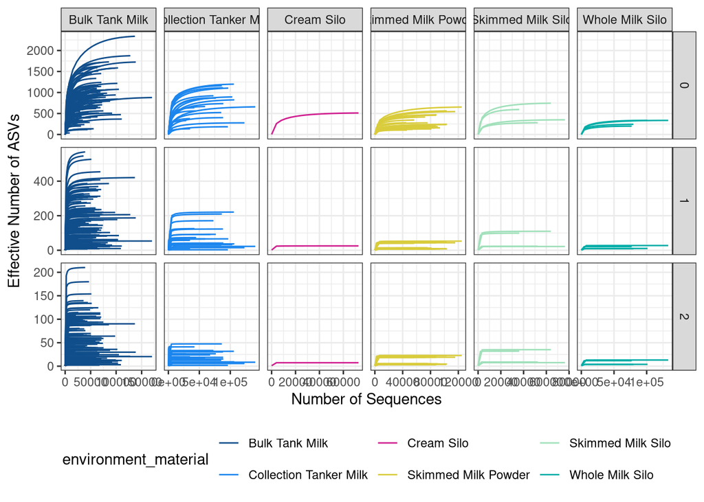

```r
# Manually plot rarefaction curves
iNEXT_manual_df_cut %>%
  # Filter out rows that are calculated with actual sequences (no extrapolated)
  dplyr::filter(Method == "Rarefaction") %>%
  # Now, let's draw the plot!
  ggplot(aes(x = m, y = qD, color = environment_material, group = names)) +
  geom_line() +
  # Facet by environment_material
  facet_grid(Order.q~environment_material, scales = "free") +
  scale_color_manual(values = environment_colors) +
  theme_bw() +
  labs(y = "Effective Number of ASVs", x = "Number of Sequences") +
  theme(legend.position = "bottom")
```

INTERPRETATION #1: What can you conclude from the ggiNEXT and manual rarefaction curve plots? Are there “enough” sequences to analyze the samples? Is it valid to make any conclusions about species richness when q = 0? What about when q = 1? Or q = 2? Why or why not?

## Testing to see if my data is “normal”

Some useful background from Mar’s analysis:

The Shapiro-Wilk test calculates a **W statistic** by comparing the order statistics (sorted values) of your data with those expected from a normal distribution.

- **W ≈ 1** → data is close to normal.
- **W < 1** → increasing deviation from normality.

What hypothses does the Shapiro-Wilk Test?

- *Null hypothesis (H₀):* The data are normally distributed.
  - *p-value > 0.05*: Fail to reject H₀ and the data appears normal.
- *Alternative hypothesis (H₁):* The data are *not* normally distributed.
  - *p-value < 0.05*: We can reject the H₀, which will indicate that the data is **not normal**.

# Run Shapiro-Wilk for richness, shannon and simpson

```r
### Now what about for richness?
obs_div_df_cut <-
  iNEXT_manual_df_cut %>%
  dplyr::filter(Method == "Observed")

save(obs_div_df_cut,
     file = "data/05_Biodiversity/obs_div_df_cut.RData")

# check it
glimpse(obs_div_df_cut)
```

```
## Rows: 576
## Columns: 65
## $ names                                    <chr> "ERR3141386", "ERR3141386", "…
## $ m                                        <dbl> 60940, 60940, 60940, 46996, 4…
## $ Method                                   <chr> "Observed", "Observed", "Obse…
## $ Order.q                                  <dbl> 0, 1, 2, 0, 1, 2, 0, 1, 2, 0,…
## $ qD                                       <dbl> 823.000000, 73.060158, 17.983…
## $ qD.LCL                                   <dbl> 813.122172, 71.715217, 17.667…
## $ qD.UCL                                   <dbl> 832.877828, 74.405099, 18.299…
## $ SC                                       <dbl> 0.9994585, 0.9994585, 0.99945…
## $ SC.LCL                                   <dbl> 0.9992641, 0.9992641, 0.99926…
## $ SC.UCL                                   <dbl> 0.9996530, 0.9996530, 0.99965…
## $ Assay.Type                               <chr> "AMPLICON", "AMPLICON", "AMPL…
## $ AvgSpotLen                               <dbl> 502, 502, 502, 502, 502, 502,…
## $ Bases                                    <dbl> 99546098, 99546098, 99546098,…
```

[output cut: 52 more lines]

```r
# Look at richness
obs_whole_rich_df_cut <-
  obs_div_df_cut %>%
  dplyr::filter(Order.q == 0)

# Test of the data is normal for richness
shapiro.test(obs_whole_rich_df_cut$qD)
```

```
##
##  Shapiro-Wilk normality test
##
## data:  obs_whole_rich_df_cut$qD
## W = 0.95433, p-value = 7.652e-06
```

```r
# Look at shannon
obs_whole_shannon_df_cut <-
  obs_div_df_cut %>%
  dplyr::filter(Order.q == 1)

# Test of the data is normal for shannon
shapiro.test(obs_whole_shannon_df_cut$qD)
```

```
##
##  Shapiro-Wilk normality test
##
## data:  obs_whole_shannon_df_cut$qD
## W = 0.88231, p-value = 4.072e-11
```

```r
# Look at simpson
obs_whole_simpson_df_cut <-
  obs_div_df_cut %>%
  dplyr::filter(Order.q == 2)

# Test of the data is normal for simpson
shapiro.test(obs_whole_simpson_df_cut$qD)
```

```
##
##  Shapiro-Wilk normality test
##
## data:  obs_whole_simpson_df_cut$qD
## W = 0.83551, p-value = 1.843e-13
```

Indicated richness is not normal! p-value = 7.652e-06 (p-value < 0.05)

Indicated Shannon diversity is not normal! p-value = 4.072e-11 (p-value < 0.05)

Indicated Simpson diversity is not normal! p-value = 1.843e-13 (p-value < 0.05)

Now I want to look at diversity by sample type (where the sample was coming from, ex. Bulk Tank, Skim Milk Powder etc.)

### Diversity by Sample Type

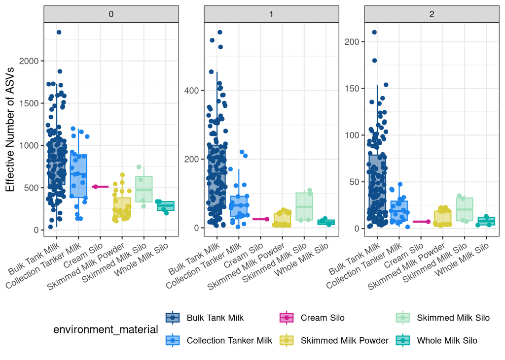

```r
# Plot boxplots by sample type against diversity
obs_div_df_cut %>%
  ggplot(aes(x = environment_material, y = qD, fill = environment_material,
             color = environment_material)) +
  facet_wrap(.~Order.q, scales = "free_y") +
  geom_jitter() +
  geom_boxplot(alpha = 0.5, outlier.shape = NA) +
  scale_color_manual(values = environment_colors) +
  scale_fill_manual(values = environment_colors) +
  labs(y = "Effective Number of ASVs") +
  theme_bw() +
  theme(legend.position = "bottom",
        axis.title.x = element_blank(),
        axis.text.x = element_text(angle = 30,
                                   hjust = 1,
                                   vjust = 1))
```

# Statistically Test Richness

```r
#Use this chunk to run stats on richness
#Right now, would need to use not normal test

# Pull out richness data
obs_rich_df_cut <-
  obs_div_df_cut %>%
  dplyr::filter(Order.q == 0)

obs_rich_df_cut$environment_material <- factor(
  obs_rich_df_cut$environment_material,
  levels = c("Bulk Tank Milk", "Collection Tanker Milk", "Whole Milk Silo", "Cream Silo", "Skimmed Milk Silo", "Skimmed Milk Powder")
)


# Perform Kruskal-Wallis test on richness by sample type
kruskal_sample_rich <- obs_rich_df_cut %>%
  kruskal_test(qD ~ environment_material)


# Look at it
kruskal_sample_rich
```

```
## # A tibble: 1 × 6
##   .y.       n statistic    df        p method
## * <chr> <int>     <dbl> <int>    <dbl> <chr>
## 1 qD      192      56.7     5 5.95e-11 Kruskal-Wallis
```

p-value: 5.952e-11

This is extremely small (0.00000000005952), meaning the test found a highly significant difference in richness across at least some of the groups.

I am now going to run a post hoc test (Dunn’s test) to see which groups differ!

```r
# post-hoc test with Dunn's Test
dunn_sample_envmat_rich <-
  obs_rich_df_cut %>%
  dunn_test(qD ~ environment_material, p.adjust.method = "fdr") %>%
  add_xy_position(x = "environment_material")


# look at the pairwise
dunn_sample_envmat_rich
```

```
## # A tibble: 15 × 13
##    .y.   group1      group2    n1    n2 statistic        p    p.adj p.adj.signif
##    <chr> <chr>       <chr>  <int> <int>     <dbl>    <dbl>    <dbl> <chr>
##  1 qD    Bulk Tank … Colle…   134    22   -1.60   1.09e- 1 2.72e- 1 ns
##  2 qD    Bulk Tank … Whole…   134     4   -2.92   3.46e- 3 1.73e- 2 *
##  3 qD    Bulk Tank … Cream…   134     1   -0.777  4.37e- 1 6.56e- 1 ns
##  4 qD    Bulk Tank … Skimm…   134     4   -1.66   9.59e- 2 2.72e- 1 ns
##  5 qD    Bulk Tank … Skimm…   134    27   -7.01   2.44e-12 3.66e-11 ****
##  6 qD    Collection… Whole…    22     4   -2.05   4.03e- 2 1.51e- 1 ns
##  7 qD    Collection… Cream…    22     1   -0.402  6.88e- 1 7.94e- 1 ns
##  8 qD    Collection… Skimm…    22     4   -0.875  3.81e- 1 6.36e- 1 ns
##  9 qD    Collection… Skimm…    22    27   -3.86   1.13e- 4 8.45e- 4 ***
## 10 qD    Whole Milk… Cream…     4     1    0.630  5.29e- 1 6.61e- 1 ns
## 11 qD    Whole Milk… Skimm…     4     4    0.903  3.66e- 1 6.36e- 1 ns
## 12 qD    Whole Milk… Skimm…     4    27    0.0104 9.92e- 1 9.92e- 1 ns
## 13 qD    Cream Silo  Skimm…     1     4   -0.0583 9.53e- 1 9.92e- 1 ns
## 14 qD    Cream Silo  Skimm…     1    27   -0.686  4.93e- 1 6.61e- 1 ns
## 15 qD    Skimmed Mi… Skimm…     4    27   -1.18   2.37e- 1 5.08e- 1 ns
## # ℹ 4 more variables: y.position <dbl>, groups <named list>, xmin <dbl>,
## #   xmax <dbl>
```

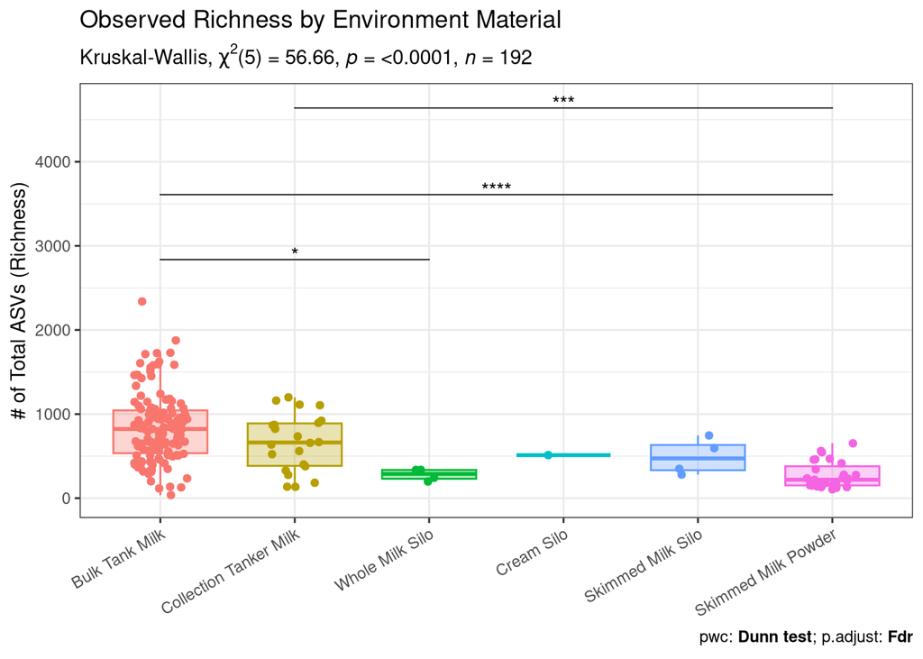

```r
#plot it
richness_boxplot_envmat <-
  ggboxplot(obs_rich_df_cut,
            x = "environment_material",
            y = "qD",
            color = "environment_material",
            fill = "environment_material",
            alpha = 0.3,
            outlier.shape = NA) +
  geom_jitter(aes(color = environment_material), width = 0.2, size = 1.5) +
  labs(y = "# of Total ASVs (Richness)",
       title = "Observed Richness by Environment Material") +
  stat_pvalue_manual(dunn_sample_envmat_rich, hide.ns = TRUE,
                     tip.length = 0, step.increase = 0.0000025) +
  labs(subtitle = get_test_label(kruskal_sample_rich, detailed = TRUE),
       caption = get_pwc_label(dunn_sample_envmat_rich)) +
  theme_bw() +
  theme(legend.position = "none",
        axis.title.x = element_blank(),
        axis.text.x = element_text(angle = 30, hjust = 1, vjust = 1)) +
  scale_y_continuous(limits = c(0, 4700))


#look at it
richness_boxplot_envmat
```

```r
levels(factor(obs_rich_df_cut$environment_material))
```

```
## [1] "Bulk Tank Milk"         "Collection Tanker Milk" "Whole Milk Silo"
## [4] "Cream Silo"             "Skimmed Milk Silo"      "Skimmed Milk Powder"
```

```r
unique(dunn_sample_envmat_rich$group1)
```

```
## [1] "Bulk Tank Milk"         "Collection Tanker Milk" "Whole Milk Silo"
## [4] "Cream Silo"             "Skimmed Milk Silo"
```

```r
unique(dunn_sample_envmat_rich$group2)
```

```
## [1] "Collection Tanker Milk" "Whole Milk Silo"        "Cream Silo"
## [4] "Skimmed Milk Silo"      "Skimmed Milk Powder"
```

First of all, here I want to note that I reordered the order of my sample types on the x-axis to reflect the order they were collected in the manufacturing pipeline (from bulk tank samples which are least processed, to the final skimmed milk powder).

You can see that there is a significant difference in richness (# of total ASVs) between Bulk Tank milk samples and Whole Milk Silo samples, as well as SKimmed Milk Powder samples. There was also a significant difference in richness between Collection Tanker Milk samples and Skimmed Milk Powder samples.

# Statistically Test Shannon Diversity

```r
# Pull out shannon data
obs_shannon_df <- obs_div_df_cut %>%
  dplyr::filter(Order.q == 1)

obs_shannon_df$environment_material <- factor(
  obs_shannon_df$environment_material,
  levels = c("Bulk Tank Milk", "Collection Tanker Milk", "Whole Milk Silo", "Cream Silo", "Skimmed Milk Silo", "Skimmed Milk Powder")
)

# Perform Kruskal-Wallis test on Shannon Diversity by sample type
kruskal_sample_shannon <- obs_shannon_df %>%
  kruskal_test(qD ~ environment_material)

# post-hoc test with Dunn's Test
dunn_sample_shannon <- obs_shannon_df %>%
  dunn_test(qD ~ environment_material, p.adjust.method = "fdr") %>%
  add_xy_position(x = "environment_material")

# look at the pairwise
dunn_sample_shannon
```

```
## # A tibble: 15 × 13
##    .y.   group1      group2    n1    n2 statistic        p    p.adj p.adj.signif
##    <chr> <chr>       <chr>  <int> <int>     <dbl>    <dbl>    <dbl> <chr>
##  1 qD    Bulk Tank … Colle…   134    22   -3.29   9.99e- 4 7.49e- 3 **
##  2 qD    Bulk Tank … Whole…   134     4   -3.13   1.74e- 3 8.72e- 3 **
##  3 qD    Bulk Tank … Cream…   134     1   -1.38   1.67e- 1 3.30e- 1 ns
##  4 qD    Bulk Tank … Skimm…   134     4   -1.71   8.69e- 2 2.61e- 1 ns
##  5 qD    Bulk Tank … Skimm…   134    27   -7.56   4.15e-14 6.22e-13 ****
##  6 qD    Collection… Whole…    22     4   -1.53   1.26e- 1 3.15e- 1 ns
##  7 qD    Collection… Cream…    22     1   -0.615  5.38e- 1 8.08e- 1 ns
##  8 qD    Collection… Skimm…    22     4   -0.205  8.37e- 1 9.17e- 1 ns
##  9 qD    Collection… Skimm…    22    27   -2.91   3.57e- 3 1.34e- 2 *
## 10 qD    Whole Milk… Cream…     4     1    0.181  8.56e- 1 9.17e- 1 ns
## 11 qD    Whole Milk… Skimm…     4     4    1.02   3.09e- 1 5.14e- 1 ns
## 12 qD    Whole Milk… Skimm…     4    27   -0.0103 9.92e- 1 9.92e- 1 ns
## 13 qD    Cream Silo  Skimm…     1     4    0.463  6.44e- 1 8.78e- 1 ns
## 14 qD    Cream Silo  Skimm…     1    27   -0.204  8.38e- 1 9.17e- 1 ns
## 15 qD    Skimmed Mi… Skimm…     4    27   -1.35   1.76e- 1 3.30e- 1 ns
## # ℹ 4 more variables: y.position <dbl>, groups <named list>, xmin <dbl>,
## #   xmax <dbl>
```

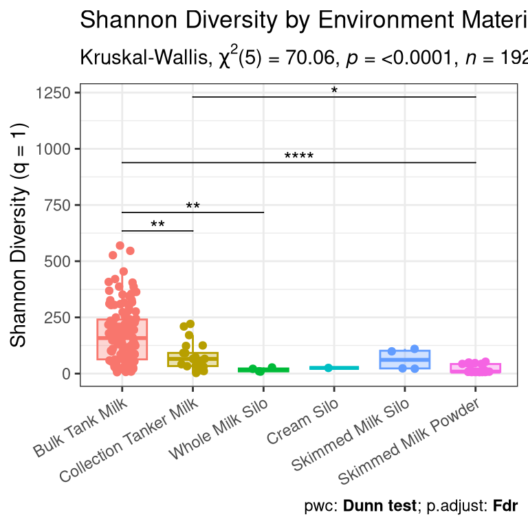

```r
#plot it
shannon_boxplot_envmat <-
  ggboxplot(obs_shannon_df,
            x = "environment_material",
            y = "qD",
            color = "environment_material",
            fill = "environment_material",
            alpha = 0.3,
            outlier.shape = NA) +
  geom_jitter(aes(color = environment_material), width = 0.2, size = 1.5) +
  labs(y = "Shannon Diversity (q = 1)",
       title = "Shannon Diversity by Environment Material") +
  stat_pvalue_manual(dunn_sample_shannon, hide.ns = TRUE,
                     tip.length = 0, step.increase = 0.01) +
  labs(subtitle = get_test_label(kruskal_sample_shannon, detailed = TRUE),
       caption = get_pwc_label(dunn_sample_shannon)) +
  theme_bw() +
  theme(legend.position = "none",
        axis.title.x = element_blank(),
        axis.text.x = element_text(angle = 30, hjust = 1, vjust = 1))

#look at it
shannon_boxplot_envmat
```

# Statistically Test Simpson Diversity

```r
# Pull out simpson data
obs_simpson_df <- obs_div_df_cut %>%
  dplyr::filter(Order.q == 2)

obs_simpson_df$environment_material <- factor(
  obs_simpson_df$environment_material,
  levels = c("Bulk Tank Milk", "Collection Tanker Milk", "Whole Milk Silo", "Cream Silo", "Skimmed Milk Silo", "Skimmed Milk Powder")
)

# Perform Kruskal-Wallis test on simpson Diversity by sample type
kruskal_sample_simpson <- obs_simpson_df %>%
  kruskal_test(qD ~ environment_material)


# post-hoc test with Dunn's Test
dunn_sample_simpson <- obs_simpson_df %>%
  dunn_test(qD ~ environment_material, p.adjust.method = "fdr") %>%
  add_xy_position(x = "environment_material")

# look at the pairwise
dunn_sample_simpson
```

```
## # A tibble: 15 × 13
##    .y.   group1       group2    n1    n2 statistic        p   p.adj p.adj.signif
##    <chr> <chr>        <chr>  <int> <int>     <dbl>    <dbl>   <dbl> <chr>
##  1 qD    Bulk Tank M… Colle…   134    22   -2.99   2.83e- 3 1.83e-2 *
##  2 qD    Bulk Tank M… Whole…   134     4   -2.91   3.65e- 3 1.83e-2 *
##  3 qD    Bulk Tank M… Cream…   134     1   -1.37   1.72e- 1 3.98e-1 ns
##  4 qD    Bulk Tank M… Skimm…   134     4   -1.32   1.87e- 1 3.98e-1 ns
##  5 qD    Bulk Tank M… Skimm…   134    27   -6.34   2.25e-10 3.38e-9 ****
##  6 qD    Collection … Whole…    22     4   -1.45   1.47e- 1 3.98e-1 ns
##  7 qD    Collection … Cream…    22     1   -0.670  5.03e- 1 7.23e-1 ns
##  8 qD    Collection … Skimm…    22     4    0.0316 9.75e- 1 9.75e-1 ns
##  9 qD    Collection … Skimm…    22    27   -2.27   2.33e- 2 8.75e-2 ns
## 10 qD    Whole Milk … Cream…     4     1    0.0925 9.26e- 1 9.75e-1 ns
## 11 qD    Whole Milk … Skimm…     4     4    1.14   2.55e- 1 4.25e-1 ns
## 12 qD    Whole Milk … Skimm…     4    27    0.255  7.98e- 1 9.75e-1 ns
## 13 qD    Cream Silo   Skimm…     1     4    0.628  5.30e- 1 7.23e-1 ns
## 14 qD    Cream Silo   Skimm…     1    27    0.0327 9.74e- 1 9.75e-1 ns
## 15 qD    Skimmed Mil… Skimm…     4    27   -1.25   2.12e- 1 3.98e-1 ns
## # ℹ 4 more variables: y.position <dbl>, groups <named list>, xmin <dbl>,
## #   xmax <dbl>
```

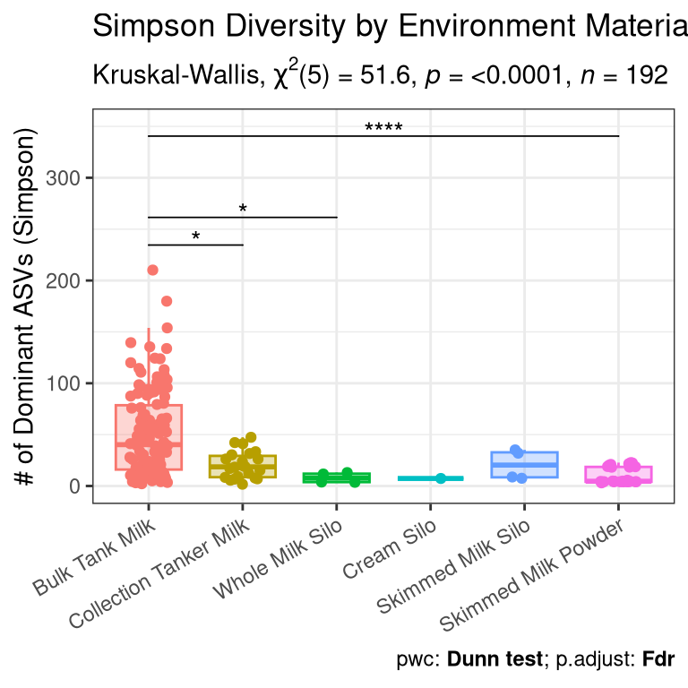

```r
#plot it
simpson_boxplot_envmat <-
  ggboxplot(obs_simpson_df,
            x = "environment_material",
            y = "qD",
            color = "environment_material",
            fill = "environment_material",
            alpha = 0.3,
            outlier.shape = NA) +
  geom_jitter(aes(color = environment_material), width = 0.2, size = 1.5) +
  labs(y = "# of Dominant ASVs (Simpson)",
       title = "Simpson Diversity by Environment Material") +
  stat_pvalue_manual(dunn_sample_simpson, hide.ns = TRUE,
                     tip.length = 0, step.increase = 0.0025) +
  labs(subtitle = get_test_label(kruskal_sample_simpson, detailed = TRUE),
       caption = get_pwc_label(dunn_sample_simpson)) +
  theme_bw() +
  theme(legend.position = "none",
        axis.title.x = element_blank(),
        axis.text.x = element_text(angle = 30, hjust = 1, vjust = 1)) +
  scale_y_continuous(limits = c(0, 350))


#look at it
simpson_boxplot_envmat
```

[figure not shown]

```r
#combine the plots

richness_boxplot_envmat + shannon_boxplot_envmat + simpson_boxplot_envmat
```

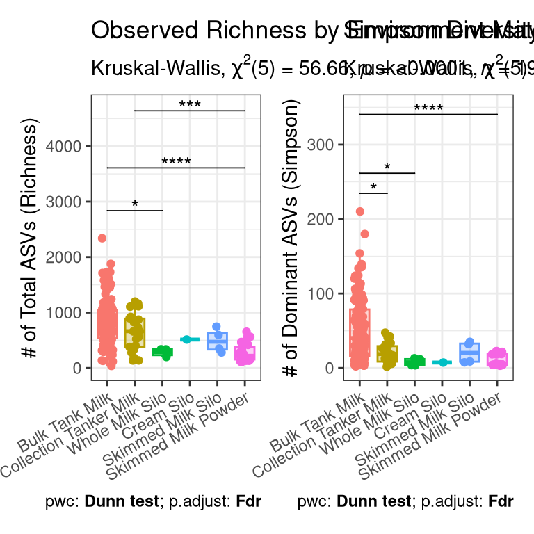

```r
#For presentation combine the richness and simpson plots! (tie it back to alternative hypothesis at beginning)
richness_boxplot_envmat + simpson_boxplot_envmat
```

INTERPRETATION #2: If you have categorical data, what can you conclude regarding the role that all ASVs (richess, q = 0) versus common ASVs (Shannon, q = 1) versus dominant ASVs (Simpson, q = 2) have on the biodiversity of your samples as it relates to your variable of interest?

Note that my variable of interest is sample type, which describes the step/stage in the dairy processing chain the sample came from!

Simpson Diversity (q=2): - Simpson diversity emphasizes the most abundant ASVs (the dominant ASVs) in the community. The Simpson diversity of the Bulk Tank Milk samples was significantly different from the Collection Tanker Milk, Skimmed Milk Powder, and Whole Milk Silo samples. There was no significant difference in the Simpson diversity between the Collection Tanker Milk samples and Skimmed Milk Powder, like was found in both the richness and Shannon.

Note that in all three measures used, Bulk Tank Milk samples had the highest alpha diversity. Also note that in all three measures of alpha diversity there were no significant differences between Bulk Tank Milk and Cream Silo. I believe this is simply because the Cream Silo has an n = 1 (only one sample from the cream silo was taken) and thus no pairwise comparisons between Cream Silo and other sample types would be seen as statistically significant?

INTERPRETATION #3: How did you statistically test your scientific question in Interpretation #2? Why?

To statistically test my scientific question, I first ran a Kruskal-Wallis test for each alpha diversity measure I was assessing (richness, Shannon diversity, Simpson diversity). I chose the Kruskal-Wallis test because my data was NOT normally distributed (which I identified with the Shapiro-Wilk normality test) and I wanted to compare alpha diversity between more than two groups. As Mar explained in class, Kruskal-Wallis is sort of the non-parametric alternative to the parametric ANOVA test.

All of my Kruskal-Wallis tests identified at least one significant difference between my groups, so I followed up with a post hoc test (Dunn’s test). To identify which pairs of groups were significantly different. I also applied p-value corrections (FDR), like Mar did in their analysis, which I believe controls the expected proportion of false positive discoveries among all rejected null hypotheses.

# Final Thoughts

In general, I found that more processed samples, with the exception of skim milk silo samples, have fewer total ASVs identified. More processed samples also have fewer dominant ASVs (potentially indicating that these samples are more dominated by a smaller number of species and the community is less balanced and less even).

These results line up with my alternative hypothesis well, as it’s pretty clear to see that raw bulk tank milk has more richness and more dominant ASVs contributing to the community.

*These results are cool because they could be interpreted as an indicator, not a confirmation though, that certain processes such as pasteurization, are working as intended in the pipeline!!!*

Also looking at alpha diversity loss could potentially help identify stages where bacteria are more resilient in the manufacturing pipeline and where spoilage or pathogenic bacteria have increased risk of becoming a problem.

# Final info for Reproducibility

## Check Render Time

```r
# Take the time now that we are at the end of the script
end_time <- Sys.time()
end_time
```

```
## [1] "2025-05-01 21:28:28 EDT"
```

```r
# Echo the elapsed time
elapsed_time <- round((end_time - start_time), 3)
elapsed_time
```

```
## Time difference of 20.721 secs
```